# Assignment 5

In this assignment, you'll scrape text from [The California Aggie](https://theaggie.org/) and then analyze the text.

The Aggie is organized by category into article lists. For example, there's a [Campus News](https://theaggie.org/campus/) list, [Arts & Culture](https://theaggie.org/arts/) list, and [Sports](https://theaggie.org/sports/) list. Notice that each list has multiple pages, with a maximum of 15 articles per page.

The goal of exercises 1.1 - 1.3 is to scrape articles from the Aggie for analysis in exercise 1.4.

**Exercise 1.1.** Write a function that extracts all of the links to articles in an Aggie article list. The function should:

- Have a parameter `url` for the URL of the article list.
- Have a parameter `page` for the number of pages to fetch links from. The default should be `1`.
- Return a list of aricle URLs (each URL should be a string).

Test your function on 2-3 different categories to make sure it works.

Hints:

- Be polite to The Aggie and save time by setting up [requests_cache](https://pypi.python.org/pypi/requests-cache) before you write your function.
- Start by getting your function to work for just 1 page. Once that works, have your function call itself to get additional pages.
- You can use [lxml.html](http://lxml.de/lxmlhtml.html) or [BeautifulSoup](https://www.crummy.com/software/BeautifulSoup/bs4/doc/) to scrape HTML. Choose one and use it throughout the entire assignment.

```python
from bs4 import BeautifulSoup
import requests_cache
import requests
import nltk
import pandas as pd
from sklearn.feature_extraction.text import TfidfVectorizer
from nltk.stem import WordNetLemmatizer
import numpy as np
from nltk.corpus import stopwords
import string
from matplotlib import pyplot as plt

requests_cache.install_cache("cache2")
```

```python
url = 'https://theaggie.org/campus/'

#init these outside because of self-calling
page_count = 1 #init page count to keep track
link_list = [] #init list of links
def get_links(url, page = 1):
    '''
    This function takes a base url for the category of new and fetches the links for the desired
    number of articles given by the page argument.
    Input: string, base url
    Output: list of article url strings.
    '''
    #declare global vars.
    global res_links
    global page_count
    global link_list
    #special base url if just 1 page requested
    if page_count == 1:
        req = requests.get(url) #request from url
    #other amount of pages
    else: req = requests.get('{}page/{}/'.format(url, page_count))
    #continue if request successful
    if req.status_code == 200:
        #use beautifulsoup for extracting link
        bsoup_obj = BeautifulSoup(req.text, 'lxml')
        for e in bsoup_obj('h2'): #shortcut for bsou_obj.find_all
            link_list.append(str(e.a['href'])) #append found link
    else: #for unsuccessful request
        page_count = page #set page_count to cease
    page_count += 1 #count page
    if page_count <= page: #self-call function if not enough pages yet
        get_links(url, page) #call self
    else: #copy into another list to return since link_list reset with each self-call
        res_links = list(link_list)
        link_list = [] #avoid duplicates
        page_count = 1 #reset page_count
    return res_links
get_links(url)
```

```
['https://theaggie.org/2017/02/24/2017-winter-quarter-election-results/',
 'https://theaggie.org/2017/02/23/university-of-california-davis-city-council-sever-wells-fargo-contracts/',
 'https://theaggie.org/2017/02/23/academics-unite-in-peaceful-rally-against-immigration-ban/',
 'https://theaggie.org/2017/02/23/memorial-union-to-reopen-spring-quarter/',
 'https://theaggie.org/2017/02/23/asucd-president-alex-lee-vetoes-amendment-for-creation-of-judicial-council/',
 'https://theaggie.org/2017/02/22/senate-candidate-zaki-shaheen-withdraws-from-race/',
 'https://theaggie.org/2017/02/21/uc-davis-experiences-several-recent-hate-based-crimes/',
 'https://theaggie.org/2017/02/21/uc-president-selects-gary-may-as-new-uc-davis-chancellor/',
 'https://theaggie.org/2017/02/20/katehi-controversy-prompts-decline-of-uc-administrators-seeking-profitable-subsidiary-board-positions/',
 'https://theaggie.org/2017/02/20/asucd-senate-passes-resolution-submitting-comments-on-lrdp/',
 'https://theaggie.org/2017/02/20/uc-releases-2016-annual-report-on-sustainable-practices/',
 'https://theaggie.org/2017/02/19/uc-davis-global-affairs-holds-discussion-on-president-donald-trumps-executive-orders-on-immigration/',
 'https://theaggie.org/2017/02/19/trumps-immigration-ban-affects-uc-davis-community/',
 'https://theaggie.org/2017/02/17/uc-davis-students-participate-in-uc-wide-nodapl-day-of-action/',
 'https://theaggie.org/2017/02/17/uc-davis-holds-first-mental-health-conference/']
```

**Exercise 1.2.** Write a function that extracts the title, text, and author of an Aggie article. The function should:

- Have a parameter `url` for the URL of the article.
- For the author, extract the "Written By" line that appears at the end of most articles. You don't have to extract the author's name from this line.
- Return a dictionary with keys "url", "title", "text", and "author". The values for these should be the article url, title, text, and author, respectively.

For example, for [this article](https://theaggie.org/2017/02/14/project-toto-aims-to-address-questions-regarding-city-finances/) your function should return something similar to this:

```
{
    'author': u'Written By: Bianca Antunez \xa0\u2014\xa0city@theaggie.org',
    'text': u'Davis residents create financial model to make city\'s financial state more transparent To increase transparency between the city\'s financial situation and the community, three residents created a model called Project Toto which aims to improve how the city communicates its finances in an easily accessible design. Jeff Miller and Matt Williams, who are members of Davis\' Finance and Budget Commission, joined together with Davis entrepreneur Bob Fung to create the model plan to bring the project to the Finance and Budget Commission in February, according to Kelly Stachowicz, assistant city manager. "City staff appreciate the efforts that have gone into this, and the interest in trying to look at the city\'s potential financial position over the long term," Stachowicz said in an email interview. "We all have a shared goal to plan for a sound fiscal future with few surprises. We believe the Project Toto effort will mesh well with our other efforts as we build the budget for the next fiscal year and beyond." Project Toto complements the city\'s effort to amplify the transparency of city decisions to community members. The aim is to increase the understanding about the city\'s financial situation and make the information more accessible and easier to understand. The project is mostly a tool for public education, but can also make predictions about potential decisions regarding the city\'s financial future. Once completed, the program will allow residents to manipulate variables to see their eventual consequences, such as tax increases or extensions and proposed developments "This really isn\'t a budget, it is a forecast to see the intervention of these decisions," Williams said in an interview with The Davis Enterprise. "What happens if we extend the sales tax? What does it do given the other numbers that are in?" Project Toto enables users, whether it be a curious Davis resident, a concerned community member or a city leader, with the ability to project city finances with differing variables. The online program consists of the 400-page city budget for the 2016-2017 fiscal year, the previous budget, staff reports and consultant analyses. All of the documents are cited and accessible to the public within Project Toto. "It\'s a model that very easily lends itself to visual representation," Mayor Robb Davis said. "You can see the impacts of decisions the council makes on the fiscal health of the city." Complementary to this program, there is also a more advanced version of the model with more in-depth analyses of the city\'s finances. However, for an easy-to-understand, simplistic overview, Project Toto should be enough to help residents comprehend Davis finances. There is still more to do on the project, but its creators are hard at work trying to finalize it before the 2017-2018 fiscal year budget. "It\'s something I have been very much supportive of," Davis said. "Transparency is not just something that I have been supportive of but something we have stated as a city council objective [ ] this fits very well with our attempt to inform the public of our challenges with our fiscal situation." ',
    'title': 'Project Toto aims to address questions regarding city finances',
    'url': 'https://theaggie.org/2017/02/14/project-toto-aims-to-address-questions-regarding-city-finances/'
}
```

Hints:

- The author line is always the last line of the last paragraph.
- Python 2 displays some Unicode characters as `\uXXXX`. For instance, `\u201c` is a left-facing quotation mark. You can convert most of these to ASCII characters with the method call (on a string)

  ```
  .translate({ 0x2018:0x27, 0x2019:0x27, 0x201C:0x22, 0x201D:0x22, 0x2026:0x20 })
  ```

  If you're curious about these characters, you can look them up on [this page](http://unicode.org/cldr/utility/character.jsp), or read more about [what Unicode is](http://unicode.org/standard/WhatIsUnicode.html).

```python
ar_url = 'https://theaggie.org/2017/02/14/project-toto-aims-to-address-questions-regarding-city-finances/'
def get_info(url):
    '''
    This function uses the provided article url to grab all the necessary information.
    Input: string, article url
    Output: dictionary, url, title, text, author
    '''
    info_dict = {} #init dict
    req = requests.get(url) #request
    soup = BeautifulSoup(req.text, 'lxml')

    article = soup.find('article') #locate the article tag portion
    title = article.h1.string #all titles in h1 tag
    #check for newline in last paragraph tag
    #if not, then author is in last para. of its own
    if '\n' not in article('p')[-1].contents:
        author = article('p')[-1].get_text() #author in last para.
        if 'Written' not in author: #check exception
            author = article('p')[-2].get_text() #try 2nd to last para
        #body text of article- get all text from p tags if not in author
        text = (''.join([e.get_text() for e in article('p')[:] if
        e.get_text() not in author]))
    else: #exeption-author is in last p. tag with with some body text
        #get author by splitting by newline and grabbing last portion
        author = article('p')[-1].get_text().split('\n')[-1]
        #text is portion before newline
        text = ''.join([e.get_text() for e in article('p')[:-1]]).split('\n')[0]
    if "Written" not in author: #some article has no author line (police log)
        author = 'No author'
    #translate some unicode chars
    text = text.translate({ 0x2018:0x27, 0x2019:0x27, 0x201C:0x22, 0x201D:0x22, 0x2026:0x20 })
    #final dict of all request info.
    info_dict = {'url': url, 'title': title, 'text': text, 'author': author}
    return info_dict

get_info(ar_url)
```

[output not shown]

**Exercise 1.3.** Use your functions from exercises 1.1 and 1.2 to get a data frame of 60 [Campus News](https://theaggie.org/campus/) articles and a data frame of 60 [City News](https://theaggie.org/city/) articles. Add a column to each that indicates the category, then combine them into one big data frame.

The "text" column of this data frame will be your corpus for natural language processing in exercise 1.4.

```python
def build_df(base_url, entries):
    '''
    This function takes a base url for news category as well as number of articles and returns
    a pd dataframe of all their respective info. Also add a column for category.
    Input: string, int, base url and number of entries
    '''
    #use function get_link, entries/15 for # of pages
    links = get_links(base_url, entries / 15)
    #init a dictionary with desired keys, values are lists
    all_info = {'author':[],'text':[],'title':[],'url':[]}
    for e in links: #get info for each link
        info = get_info(e) #call get_info
        for key in info.iterkeys(): #append to list of values for each key
            all_info[key].append(info[key])
    df = pd.DataFrame(all_info) #turn into pd dataframe
    #add category column
    df['category'] = base_url.split('/')[-2] + ' news'
    return df
#build df for first 60 campus news articles
campus_news = build_df('https://theaggie.org/campus/', 60)
#df for city news
city_news = build_df('https://theaggie.org/city/', 60)
#combine the two (120 rows total)
comb_df = pd.concat([campus_news, city_news], ignore_index=True)
comb_df
```

|  | author | text | title | url | category |
| --- | --- | --- | --- | --- | --- |
| 0 | Written by: Alyssa Vandenberg — campus@theagg... | Six senators, new executive team electedCurren... | 2017 Winter Quarter election results | https://theaggie.org/2017/02/24/2017-winter-qu... | campus news |
| 1 | Written by: Aaron Liss and Raul Castellanos —... | Wells Fargo faces fraud, predatory lending cha... | University of California, Davis City Council s... | https://theaggie.org/2017/02/23/university-of-... | campus news |
| 2 | Written by: Kimia Akbari — campus@theaggie.org | Faculty, students recount personal tales of im... | Academics unite in peaceful rally against immi... | https://theaggie.org/2017/02/23/academics-unit... | campus news |
| 3 | Written by: Kenton Goldsby — campus@theaggie.org | Opening date pushed back to May 1Students have... | Memorial Union to reopen Spring Quarter | https://theaggie.org/2017/02/23/memorial-union... | campus news |
| 4 | Written by: Ivan Valenzuela — campus@theaggie.org | Veto included revision abandoning creation of ... | ASUCD President Alex Lee vetoes amendment for ... | https://theaggie.org/2017/02/23/asucd-presiden... | campus news |
| 5 | Written by: Alyssa Vandenberg — campus@theagg... | Shaheen's name to remain on ballot, his votes ... | Senate candidate Zaki Shaheen withdraws from race | https://theaggie.org/2017/02/22/senate-candida... | campus news |
| 6 | Written by: Aaron Liss — campus@theaggie.org | Students receive email warnings from UC Davis ... | UC Davis experiences several recent hate-based... | https://theaggie.org/2017/02/21/uc-davis-exper... | campus news |
| 7 | Written by: Alyssa Vandenberg — campus@theagg... | UC Board of Regents to vote on the appointment... | UC President selects Gary May as new UC Davis ... | https://theaggie.org/2017/02/21/uc-president-s... | campus news |
| 8 | Written by: Jeanna Totah — campus@theaggie.org | Tighter policies require greater approval of o... | Katehi controversy prompts decline of UC admin... | https://theaggie.org/2017/02/20/katehi-controv... | campus news |
| 9 | Written by: Ivan Valenzuela — campus@theaggie... | SR #7 asks university to increase capacity for... | ASUCD Senate passes resolution submitting comm... | https://theaggie.org/2017/02/20/asucd-senate-p... | campus news |
| 10 | Written by: Yvonne Leong — campus@theaggie.org | UC Davis leads in sustainability with largest ... | UC releases 2016 Annual Report on Sustainable ... | https://theaggie.org/2017/02/20/uc-releases-20... | campus news |
| 11 | Written by: Kenton Goldsby — campus@theaggie.org | Speakers, including Interim Chancellor Ralph J... | UC Davis Global Affairs holds discussion on Pr... | https://theaggie.org/2017/02/19/uc-davis-globa... | campus news |
| 12 | Written by: Kimia Akbari — campus@theaggie.org | Executive order has immediate consequences for... | Trump’s immigration ban affects UC Davis commu... | https://theaggie.org/2017/02/19/trumps-immigra... | campus news |
| 13 | Written by: Kaitlyn Cheung — campus@theaggie.org | Student protesters march from MU flagpole to M... | UC Davis students participate in UC-wide #NoDA... | https://theaggie.org/2017/02/17/uc-davis-stude... | campus news |
| 14 | Written by: Jayashri Padmanabhan — campus@thea... | Conference entails full day of speakers, panel... | UC Davis holds first mental health conference | https://theaggie.org/2017/02/17/uc-davis-holds... | campus news |
| 15 | Written by: Demi Caceres — campus@theaggie.org | Last week in SenateThe ASUCD Senate meeting wa... | Last week in Senate | https://theaggie.org/2017/02/16/last-week-in-s... | campus news |
| 16 | Written by: Alyssa Vandenberg and Emilie DeFaz... | Executive: Josh Dalavai and Adilla JamaludinIn... | 2017 ASUCD Winter Elections — Meet the Candidates | https://theaggie.org/2017/02/16/2017-asucd-win... | campus news |
| 17 | Written by: Ivan Valenzuela — campus@theaggie.org | New showcase provides opportunity for students... | Shields Library hosts new exhibit for Davis ce... | https://theaggie.org/2017/02/14/shields-librar... | campus news |
| 18 | Written by: Demi Caceres — campus@theaggie.org | Students promote fruit and vegetable meals via... | Student Health and Counseling Services hosts “... | https://theaggie.org/2017/02/14/student-health... | campus news |
| 19 | Written by: Lindsay Floyd — campus@theaggie.org | New fees to pay for equipment replacementTo co... | PE classes may charge additional fees | https://theaggie.org/2017/02/13/pe-classes-may... | campus news |
| 20 | Written by: Jeanna Totah — campus@theaggie.org | Recipients each rewarded $25,000 for researchU... | 11 new Chancellor Fellows honored for 2016 | https://theaggie.org/2017/02/12/11-new-chancel... | campus news |
| 21 | Written by: Aaron Liss — campus@theaggie.org | Muslim Student Association curates five-part D... | Muslim students respond to recent political ev... | https://theaggie.org/2017/02/12/muslim-student... | campus news |
| 22 | Written by: Lindsay Floyd — campus@theaggie.or... | Events to promote safe sexOn Feb. 1, Student H... | Sexcessful Campaign launched in time for Valen... | https://theaggie.org/2017/02/12/sexcessful-cam... | campus news |
| 23 | Written by: Alyssa Vandenberg — campus@theagg... | Chan replaces former senator Sam ParkMichael C... | Michael Chan sworn in as interim senator | https://theaggie.org/2017/02/10/michael-chan-s... | campus news |
| 24 | Written by: Kenton Goldsby — campus@theaggie.org | Regents approve tuition increase in 16-4 voteT... | University of California Regents meet, approve... | https://theaggie.org/2017/02/09/university-of-... | campus news |
| 25 | Written by: Yvonne Leong — campus@theaggie.org | Last week in SenateThe ASUCD Senate meeting wa... | Last week in Senate | https://theaggie.org/2017/02/09/last-week-in-s... | campus news |
| 26 | Written by: Jayashri Padmanabhan — campus@thea... | Funding to expand innovation, entrepreneurship... | UC Davis receives $2.2 million from Assembly B... | https://theaggie.org/2017/02/09/uc-davis-recei... | campus news |
| 27 | Written by: Ivan Valenzuela — campus@theaggie.org | Davis College Democrats host Dodd for question... | Senator Bill Dodd visits UC Davis | https://theaggie.org/2017/02/06/senator-bill-d... | campus news |
| 28 | Written by: Kenton Goldsby — campus@theaggie.org | Law to affect students selected to attend Nati... | AB 1887 prevents use of state funds, including... | https://theaggie.org/2017/02/05/ab-1887-preven... | campus news |
| 29 | Written by: Jayashri Padmanabhan — campus@thea... | Kathleen Salvaty to oversee implementation of ... | UC system hires Title IX coordinator | https://theaggie.org/2017/02/02/uc-system-hire... | campus news |
| ... | ... | ... | ... | ... | ... |
| 90 | Written by: Raul Castellanos Jr. — city@theagg... | Downtown Davis offers a wide range of Thai cui... | No such thing as too much Thai food | https://theaggie.org/2017/01/17/no-such-thing-... | city news |
| 91 | Written by: Kaelyn Tuermer-Lee – city@theaggie... | Petco Foundation awards $10,000 to local anima... | A dog named Disney wins grant money for Rotts ... | https://theaggie.org/2017/01/16/a-dog-named-di... | city news |
| 92 | Written by: Andie Joldersma — city@theaggie.org | Books by Mail program will deliver materials s... | Yolo County Library materials to be more widel... | https://theaggie.org/2017/01/15/yolo-county-li... | city news |
| 93 | Written by: Sam Solomon — city@theaggie.org | Season's Greetings EditionDec. 24"Downstairs n... | Police Logs | https://theaggie.org/2017/01/12/police-logs-7/ | city news |
| 94 | Written By: Dianna Rivera — city@theaggie.org | The Davis Manor Neighborhood hosts first Holid... | Neighbors unite | https://theaggie.org/2017/01/12/neighbors-unite/ | city news |
| 95 | Written by: Kaelyn Tuermer-Lee — city@theaggie... | Local author Matt Biers-Ariel's latest novelMa... | Sparks fly in Light the Fire | https://theaggie.org/2016/12/09/sparks-fly-in-... | city news |
| 96 | Written by: Raul Castellanos Jr. — city@theagg... | Volunteer program distributes bicycles, aims t... | Bike Campaign offers bicycles to those who can... | https://theaggie.org/2016/12/09/bike-campaign-... | city news |
| 97 | Written By: Juno Bhardwaj-shah — city@theaggie... | Speakers criticize "unconstitutional" systemOn... | Bail reform advocates gather at annual fundraiser | https://theaggie.org/2016/12/08/bail-reform-ad... | city news |
| 98 | Written by: Samantha Solomon – city@theaggie.org | Live-action retelling of Christmas poem promis... | ‘Twas the Night Before Christmas in Old Sacram... | https://theaggie.org/2016/12/07/twas-the-night... | city news |
| 99 | Written by: Sam Solomon — city@theaggie.org | 35th annual tree lighting ceremony kicks off w... | Children’s Candlelight Parade lights up downto... | https://theaggie.org/2016/12/05/childrens-cand... | city news |
| 100 | Written by: Sam Solomon – city@theaggie.org | Another week of 'why did people call the polic... | Police Logs | https://theaggie.org/2016/12/04/police-logs-6/ | city news |
| 101 | Written By: Dianna Rivera – city@theaggie.org | The Yolo County Children's Alliance celebrates... | The season of giving | https://theaggie.org/2016/12/04/the-season-of-... | city news |
| 102 | Written by: Samantha Solomon — city@theaggie.org | Students, activists call for solidarity with S... | NoDAPL protest erupts in downtown Davis | https://theaggie.org/2016/12/02/nodapl-protest... | city news |
| 103 | Written by: Andie Joldersma — city@theaggie.org | Participants gathered for 5k, 10k, half marath... | Davis Turkey Trot: more than just another race | https://theaggie.org/2016/12/02/davis-turkey-t... | city news |
| 104 | Written By: Andie Joldersma — city@theaggie.org | Citizens can expect more cost-competitive clea... | Affordable, clean, green energy is coming to Y... | https://theaggie.org/2016/11/30/affordable-cle... | city news |
| 105 | Written by: Bianca Antunez – city@theaggie.org | Davis community renews local parcel tax for K-... | Measure H passes, voters support Davis schools | https://theaggie.org/2016/11/29/measure-h-pass... | city news |
| 106 | Written by: Anya Rehon — city@theaggie.org | College alcohol use, high-risk drinking discus... | Local residents attend Davis town hall meeting | https://theaggie.org/2016/11/29/local-resident... | city news |
| 107 | Written by: Sam Solomon – city@theaggie.org | Looks like it's been an interesting weekNov. 1... | Police Logs | https://theaggie.org/2016/11/27/police-logs-5/ | city news |
| 108 | Written by: Raul Castellanos Jr. — city@theagg... | Ornamental piano outside Mishka's Café vandali... | Public piano destroyed in act of vandalism | https://theaggie.org/2016/11/27/public-piano-d... | city news |
| 109 | Written by: Samantha Solomon – city@theaggie.org | Davis residents light candles, promote sanctua... | Holding the Light | https://theaggie.org/2016/11/27/holding-the-li... | city news |
| 110 | Written By: Dianna Rivera — city@theaggie.org | Don't be left in the dark now that Daylight Sa... | Sun down, bike lights out | https://theaggie.org/2016/11/22/sun-down-bike-... | city news |
| 111 | Written By: Sam Solomon — city@theaggie.org | Nov. 7"Subject stated our pizza is ready and t... | Police Logs | https://theaggie.org/2016/11/22/police-logs-4/ | city news |
| 112 | Written by: Kaelyn Tuermer-Lee – city@theaggie... | Helping the community through Davis Community ... | Tune in to Watermelon Music’s strings-for-food... | https://theaggie.org/2016/11/21/tune-in-to-wat... | city news |
| 113 | Written By: Andie Joldersma — city@theaggie.org | Protesters gather at State Capitol Building fo... | Water is sacred, water is life | https://theaggie.org/2016/11/20/water-is-sacre... | city news |
| 114 | Written By: Anya Rehon — city@theaggie.org | The Yolo County community comes together for h... | The Yolo Food Bank addresses food insecurity | https://theaggie.org/2016/11/17/the-yolo-food-... | city news |
| 115 | Written By: Bianca Antunez — city@theaggie.org | Election results are in; Davis community conce... | Nov. 8 2016: An Election Day many may never fo... | https://theaggie.org/2016/11/17/nov-8-2016-an-... | city news |
| 116 | No author | More turkeys, more tomfoolery, more accidental... | Police Logs | https://theaggie.org/2016/11/15/police-logs-3/ | city news |
| 117 | Written By: Bianca Antunez – city@theaggie.org | Participants line up for Thanksgiving 5k befor... | Yolo Food Bank’s eighth Annual Running of the ... | https://theaggie.org/2016/11/15/yolo-food-bank... | city news |
| 118 | Written by: Raul Castellanos — city@theaggie.org | Bernie Sanders visits Sacramento to rally for ... | Return of the Bern | https://theaggie.org/2016/11/15/return-of-the-... | city news |
| 119 | Written by: Alana Joldersma –– city@theaggie.org | Indoor facility will provide a cafeteria, clas... | Construction of the All Student Center at Davi... | https://theaggie.org/2016/11/14/construction-o... | city news |

120 rows × 5 columns

**Exercise 1.4.** Use the Aggie corpus to answer the following questions. Use plots to support your analysis.

- What topics does the Aggie cover the most? Do city articles typically cover different topics than campus articles?
- What are the titles of the top 3 pairs of most similar articles? Examine each pair of articles. What words do they have in common?
- Do you think this corpus is representative of the Aggie? Why or why not? What kinds of inference can this corpus support? Explain your reasoning.

Hints:

- The [nltk book](http://www.nltk.org/book/) and [scikit-learn documentation](http://scikit-learn.org/stable/modules/feature_extraction.html#text-feature-extraction) may be helpful here.
- You can determine whether city articles are "near" campus articles from the similarity matrix or with k-nearest neighbors.
- If you want, you can use the [wordcloud](http://amueller.github.io/word_cloud/) package to plot a word cloud. To install the package, run

  ```
  conda install -c https://conda.anaconda.org/amueller wordcloud
  ```

  in a terminal. Word clouds look nice and are easy to read, but are less precise than bar plots.

```python
#add to the default 'english' stopwords list to account for punctuations
eng_stop_mod = list(stopwords.words('english'))
for e in string.printable:
    if not e.isalpha(): #everything not alpha character
        eng_stop_mod.append(e)

tokenize = nltk.word_tokenize #nltk tokenizer
lemma = WordNetLemmatizer().lemmatize #nltk WordNetLemmatizer
def wnl_lemmatizer(text): #function to make it work for a whole text
    return [lemma(tok.lower()) for tok in tokenize(text)]

def top_words(corpus, word_num = 50):
    '''
    This function takes in the corpus, and # of words desired and returns the top words within that corpus.
    Input: list of strings, each element a body of text- corpus
    Output: list of top words
    '''
    #use tfidf and fit to corpus
    vectorizer = TfidfVectorizer(tokenizer=wnl_lemmatizer,stop_words=eng_stop_mod,smooth_idf=True,norm=None)
    fit = vectorizer.fit_transform(corpus)
    farray = fit.toarray() #represent with np array
    farray = np.vstack([farray, sum(farray)]) #additional row for sum of each col.
    #words and vocab (dict of words as keys and index as values)
    word = vectorizer.get_feature_names()
    vocab = vectorizer.vocabulary_
    #invert the vocab dict, keys-ids, values-words
    vocab_rev = {vocab[key]: key for key in vocab}
    #order the word ids descending by flipping the array up down
    ordered_word_id = list(np.flipud(np.argsort(farray[-1])))
    #list compr.  for list of top words
    top_words = [[vocab_rev[key],farray[-1,key]] for key in ordered_word_id[:word_num]]
    return top_words
aggie_corp = list(comb_df['text']) #use text column as corpus
#filtering out some words with non-alpha char. before tokenizing, fitting
aggie_corp = [''.join(ch for ch in c if ch.isalpha() or ch == ' ') for c in aggie_corp]
topw = top_words(aggie_corp, 100) #top 100 words in aggie corpus
#more filtering
topw = [e for e in topw if e[0] not in eng_stop_mod and len(e[0]) > 2]
```

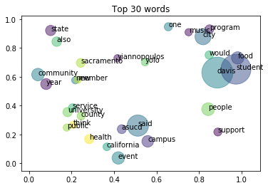

```python
#plotting bubble scatter plot of the top 30 words
N = 30
#arbitrary positions and colors
x = np.random.rand(N)
y = np.random.rand(N)
colors = np.random.rand(N)
#bubble size based on tfidf
area = np.pi * (np.array([e[1] for e in topw[:30]]) / 30)**2  # 0 to 15 point radii
#labels of the words
labels = [e[0] for e in topw[:30]]
#scatterplot
plt.scatter(x, y, s=area, c=colors, alpha=0.5)
for lab, x, y in zip(labels, x, y):
    plt.annotate(lab, xy = (x,y))
plt.title('Top 30 words')
plt.show()
```

```python
#tfidf fitting
vectorizer = TfidfVectorizer(tokenizer=wnl_lemmatizer,stop_words=eng_stop_mod,smooth_idf=True,norm=None)
fit = vectorizer.fit_transform(aggie_corp)
farray = fit.toarray()
#similarity matrix from dot product fit and its transpose
sim_mat = fit.dot(fit.T)
sim_mat = sim_mat.toarray() #to np array
ave_sim = sim_mat.mean() #overall mean similarity
#mean similarity of campus vs city compared to overall mean
sim_propor = sim_mat[0:60, 60:120].mean() / ave_sim
sim_propor
```

```
0.69863413726327184
```

[figure not shown]

[figure not shown]

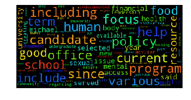

```python
#grab just upper triangle(not including main diag) since bot. left is mirrored
sim_upper_tri = np.triu(sim_mat,k = 1)
#list of list, each storing id and the actual max value for each row
col_id = [[np.argmax(sim_upper_tri[i]), np.max(sim_upper_tri[i])] for i in range(0,119)]
#list of max values from each row
row_max = [e[1] for e in col_id]
#sort the max values descending order
sorted_row_id = list(np.flipud(np.argsort(row_max)))
#v stores the top 3 max values
v = [sim_upper_tri[e[0],e[1]] for e in top3_pair_ids]
#indices of top three pairs
top3_pair_ids = [(14, col_id[14][0]), (4, col_id[4][0]),(16, col_id[16][0])]
#grab titles from the orignal combined df using the ids
top3_pair_title = [(comb_df['title'][e[0]], comb_df["title"][e[1]]) for e in top3_pair_ids]

def text_comp(text1, text2):
    '''
    simple text comparison, returns words in common
    '''
    fit1 = [w for w in wnl_lemmatizer(text1) if w not in eng_stop_mod]
    fit2 = [w for w in wnl_lemmatizer(text2) if w not in eng_stop_mod]
    return [w for w in fit1 if w in fit2]
#words in common for the top 3 most similar pairs
pair1_common = set(text_comp(aggie_corp[14], aggie_corp[35]))
pair2_common = set(text_comp(aggie_corp[4], aggie_corp[25]))
pair3_common = set(text_comp(aggie_corp[16], aggie_corp[55]))

def w_cloud(text):
    '''
    generate and show word cloud for the given text
    '''
    wc = WordCloud(max_font_size=30).generate(text)
    plt.figure()
    plt.imshow(wc)
    plt.axis("off")
    plt.show()
w_cloud(' '.join(pair1_common))
w_cloud(' '.join(pair2_common))
w_cloud(' '.join(pair3_common))
```

According to the fit using tfidf, we can gather some information about the weighted commonly occuring words in the aggie corpus. Basing off of these top words, we can see that many of them can be classified as possible topic words. As expected, among the top results, we observe topics like uc davis, university, student, city, community, food, event, asucd (associated students, uc davis). Within the top 100 words, we also see less locally-focused issues such as climate, science, pipeline, california. Also within the top 100, concurrently relevant topics like milo yiannopoulos, Trump, muslim are also present.

Using the similarity matrix, we examine that on average, the simalarity score between the campus and city articles is 410. Compared to the overall average similarity of 587, the two types of news exhibits about 70% similarity of overall. Typically, we should see overlaps in the topics of city and campus news considering also that they both tend to cover local, university-related news.

The titles of the top 3 pairs of most similar articles are: (UC Davis holds first mental health conference, UC Davis to host first ever mental health conference), ASUCD President Alex Lee vetoes amendment for creation of Judicial Council, Last week in Senate), (2017 ASUCD Winter Elections Meet the Candidates, Student regent recruitment for the 2018-2019 school year begins) The top pair is especially obvious for their similarity in content. Most notable words in common for the first pair include: administration, counseling, conference, community, mental, psychology, and health. The second pair: asucd, voting, president, student, council, court, commission, and, committee. The third pair: candidate, community, affordability, budget, campus, policy, and program. These words in common can be seen in the wordcloud for each pair.

It may be reasonable to think this corpus is representative of the aggie to some degree considering that the other categories of news may be even more locally/ucd cetered. Some examples include sports, arts and culture, and features which likely covers mostly local stories. Having so many topics covering local affairs and sentiments, this corpus could support inferences regarding the on-going topics within and surrounding the community with the occassional coverage of hot-buttoned national issues. Overal, this should be expected of a news group within a university.